# Classification model

### Required libraries

```r
library(readr)
library(rpart)
library(rattle)
library(adabag)
library(randomForest)
```

#### Importing Data

```r
df <- read_delim("data.csv", ";", escape_double = FALSE, trim_ws = TRUE)
```

#### Cleaning the data

Removing extra characters in column name by changing the column names:

```r
colnames(df)= gsub('"','',colnames(df))
```

Removing extra characters in each column values:

```r
df$age=gsub('"','',df$age)
df$job=gsub('"','',df$job)
df$marital=gsub('"','', df$marital)
df$education=gsub('"','',df$education)
df$default=gsub('"','', df$default)
df$housing=gsub('"','', df$housing)
df$loan=gsub('"','', df$loan)
df$contact=gsub('"','', df$contact)
df$month=gsub('"','', df$month)
df$poutcome=gsub('"','', df$poutcome)
df$y=gsub('"','', df$y)
```

Duplicate verification

```r
ifelse(nrow(df[(duplicated(df)) , ])==0,"No duplicate", "There are duplicated in the table")
```

```
## [1] "No duplicate"
```

Average and Median of age of the Clients accounts’ balance :

```r
summary(df)
```

```
##      age                job              marital
##  Length:45211       Length:45211       Length:45211
##  Class :character   Class :character   Class :character
##  Mode  :character   Mode  :character   Mode  :character
##
##
##
##   education           default             balance         housing
##  Length:45211       Length:45211       Min.   : -8019   Length:45211
##  Class :character   Class :character   1st Qu.:    72   Class :character
##  Mode  :character   Mode  :character   Median :   448   Mode  :character
##                                        Mean   :  1362
##                                        3rd Qu.:  1428
##                                        Max.   :102127
##      loan             contact               day           month
##  Length:45211       Length:45211       Min.   : 1.00   Length:45211
##  Class :character   Class :character   1st Qu.: 8.00   Class :character
##  Mode  :character   Mode  :character   Median :16.00   Mode  :character
##                                        Mean   :15.81
##                                        3rd Qu.:21.00
##                                        Max.   :31.00
##     duration         campaign          pdays          previous
##  Min.   :   0.0   Min.   : 1.000   Min.   : -1.0   Min.   :  0.0000
##  1st Qu.: 103.0   1st Qu.: 1.000   1st Qu.: -1.0   1st Qu.:  0.0000
##  Median : 180.0   Median : 2.000   Median : -1.0   Median :  0.0000
##  Mean   : 258.2   Mean   : 2.764   Mean   : 40.2   Mean   :  0.5803
##  3rd Qu.: 319.0   3rd Qu.: 3.000   3rd Qu.: -1.0   3rd Qu.:  0.0000
##  Max.   :4918.0   Max.   :63.000   Max.   :871.0   Max.   :275.0000
##    poutcome              y
##  Length:45211       Length:45211
##  Class :character   Class :character
##  Mode  :character   Mode  :character
##
##
##
```

Summary result shows that age variable is character so I convert it to numeric

```r
df$age=as.numeric(df$age)
```

Average and Median of age of the Clients accounts’ balance :

```r
paste("Avrage age of the clients is: ",round(mean(df$age),1), " years")
```

```
## [1] "Avrage age of the clients is:  40.9  years"
```

```r
paste("Median of age of clients is: ",median(df$age), "years")
```

```
## [1] "Median of age of clients is:  39 years"
```

Changing the name of the variable representing if the client has subscribed to direct deposit or no to ‘deposit’

```r
names(df)[grep("^y", colnames(df))]="deposit"
```

Creating the data_deposit data table which only include customers with a balance higher than 0.

```r
data_deposit=subset(df, balance > 0)
```

### Designing a classification tree on the data_deposit data using all the explanatory variables:

```r
rpart_deposit=rpart(deposit~., data_deposit, parms = list(split='gini'), control=list(maxdepth=5, minsplit=50) , method ='class')
```

### The classification tree graph

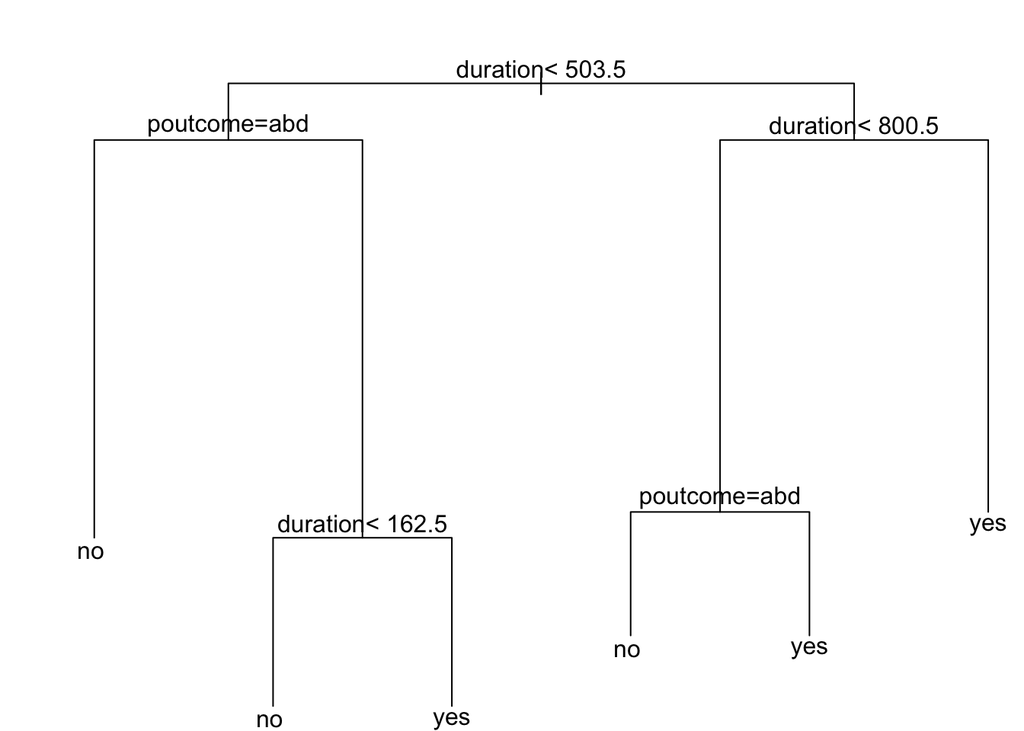

```r
par(mar=c(0,2,2,0))
plot(rpart_deposit)
text(rpart_deposit)
```

### The classification tree fancy graph

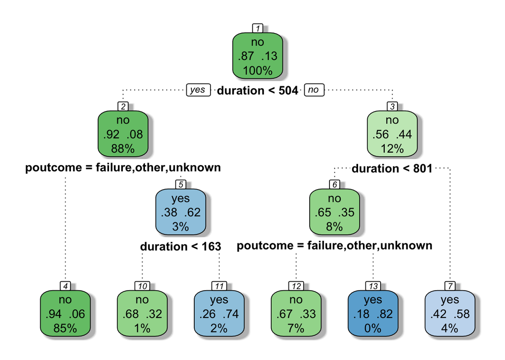

```r
fancyRpartPlot(rpart_deposit, caption = NULL)
```

### Interpretation of the first terminal leaf :

```r
rpart_deposit
```

```
## n= 37931
##
## node), split, n, loss, yval, (yprob)
##       * denotes terminal node
##
##  1) root 37931 4787 no (0.87379716 0.12620284)
##    2) duration< 503.5 33441 2826 no (0.91549296 0.08450704)
##      4) poutcome=failure,other,unknown 32226 2072 no (0.93570409 0.06429591) *
##      5) poutcome=success 1215  461 yes (0.37942387 0.62057613)
##       10) duration< 162.5 338  107 no (0.68343195 0.31656805) *
##       11) duration>=162.5 877  230 yes (0.26225770 0.73774230) *
##    3) duration>=503.5 4490 1961 no (0.56325167 0.43674833)
##      6) duration< 800.5 2852 1005 no (0.64761571 0.35238429)
##       12) poutcome=failure,other,unknown 2711  889 no (0.67207672 0.32792328) *
##       13) poutcome=success 141   25 yes (0.17730496 0.82269504) *
##      7) duration>=800.5 1638  682 yes (0.41636142 0.58363858) *
```

*poutcome=failure, other, unknown 32226 2072 no (0.93570409 0.06429591)*

The parent leaf of this terminal leaf is a 2-branch leaf :

- poutcome = failure, other, unknown (the terminal leaf that I study here)
- poutcome = success

This terminal leaf has 32226 observations of which 2072 have a deposit value of « yes » and 30152 (32226-2072) observations have a deposit value of « no ». This means that 2072 values of deposit are mis-classified.

### Two explanatory variables having the greatest importance in the construction of the tree:

```r
rpart_deposit$variable.importance[order(rpart_deposit$variable.importance, decreasing = TRUE)]
```

```
##     duration     poutcome      contact     campaign      balance
## 1180.1324878  790.2576611    2.3047268    1.4162798    0.7682423
##        pdays      default          age     previous
##    0.5121615    0.2560808    0.0679380    0.0679380
```

“duration” with importance value of 1180 and “pourcome” with importance value of 790

### Natural classification error rate in data_deposit data table:

```r
table(data_deposit$deposit)/nrow(data_deposit)
```

```
##
##        no       yes
## 0.8737972 0.1262028
```

The classification error rate is **12.6%**

## Ensemble Methods

For Ensemble Methods, the variables of type character must be converted into factors

```r
cols <- c("deposit", "job", "marital","education","housing","loan","contact","month","poutcome","default")
data_deposit[cols] <- lapply(data_deposit[cols], factor)
```

And the table should be dataframe

```r
data_deposit=data.frame(data_deposit)
```

### Designing Bagging model with 50 trees and a maximum depth of 4:

```r
bagging_deposit=bagging(deposit~.,data_deposit,mfinal=50, control=rpart.control(maxdepth=4))
```

Bagging Misclassification rate (MR)

```r
SUMM=sum(diag(table(bagging_deposit$class, data_deposit$deposit)))
MR_bagging=1-(SUMM/nrow(data_deposit))
```

### Designing Boosting model with 50 trees and a maximum depth of 4:

```r
boosting_deposit=boosting(deposit~.,data_deposit,mfinal=50, control=rpart.control(maxdepth=4))
```

Boosting Misclassification Rate (MR)

```r
SUMM=sum(diag(table(boosting_deposit$class, data_deposit$deposit)))
MR_boosting=1-(SUMM/nrow(data_deposit))
```

```r
RF_deposit=randomForest(deposit~.,data_deposit,ntree=50,mtry=5)
```

Random Forest Misclassification Rate (MR)

```r
SUMM=sum(diag(table(RF_deposit$predicted, data_deposit$deposit)))
MR_RF=1-(SUMM/nrow(data_deposit))
```

Comparing the mis-classification rates of Bagging, boosting and Random Forest methods to decide which one performs better:

```r
paste("Bagging misclassification rate is : ", MR_bagging)
```

```
## [1] "Bagging misclassification rate is :  0.105217368379426"
```

```r
paste("Boosting misclassification rate is : ", MR_boosting)
```

```
## [1] "Boosting misclassification rate is :  0.0985209986554533"
```

```r
paste("Random Forest misclassification rate is : ", MR_RF)
```

```
## [1] "Random Forest misclassification rate is :  0.103240093854631"
```

The misclassification rates of all 3 models are smaller than the classification error rate of the dataset. This means that the 3 models are efficient. But the misclassification rate of the Boosting model is the smallest of all; which means that Boosting model is the most efficient models.